# San Francisco International Airport (SFO) Customer Survey

Sandra Ezidiegwu

July 30, 2016

# Synopsis

This is a mini-project I carried to showcase my data extraction, structuring, manipulating and visualization skills. Due to the limited dataset, I was able to perform a basic analysis using the R Programming Language and Microsoft Excel.

The goal of this report is to identify possible changes that can be implemented by American Airlines (AA) to improve the customer experience of AA customers departing from the San Francisco International Airport (SFO). The results are displayed using barplots to show customer complaints count by airline, destination and complaint type.

Although the complaints raised by airline customers in the survey ranged from operational related problems such as flight delays, to technology related problems such as the absence of online baggage check-in with some airlines.

### Recommendations

Assuming these complaints are significant and representative of the feelings of the population of AA customers flying out of SFO, then based on the analysis of the survey data I would recommend the following:

- AA should investigate and address the causes of operational issues associated with Baggage Claim Difficulty
- Additional Customer Service Staff be added to help with customer questions and check-ins
- AA Customer Service Staff be routinely required to attend service training programs. Additionally, AA can implement a customer service rating rewards program to act as an incentive to Customer Service Staff to better serve AA customers.

## Consumer Survey Data Summary

These passenger datasets contain data pertaining to customer demographics and satisfaction with Airport facilities, services, and initiatives. The Customer Survey is conducted annually.

Data Source: http://www.flysfo.com/media/customer-survey-data

## Survey Data Breakdown and Analysis

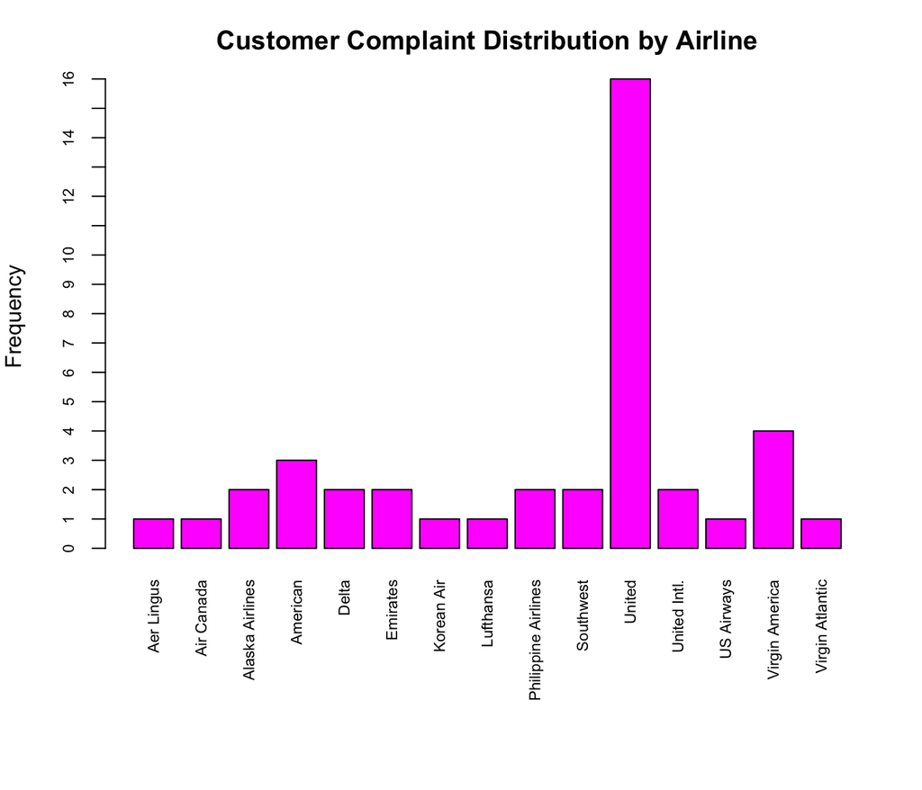

The plot above shows a distribution of customer complaints by airline departing San Francisco International Airport.

Although this chart above infers that United Airlines (UA) has the most customer complaints, we cannot conclude that UA customers are the more dissatisfied than other airline customers. The complaint count for UA in comparison to other airlines may have resulted from UA accounting for a larger percent of all departing flights from SFO. With total departing flight count per airline, and total airline customer size data unavailable, normalization to evaluate this dataset could not be carried out to arrive at a solid conclusion.

## Customer Complaint Distribution for all SFO Departing Flights

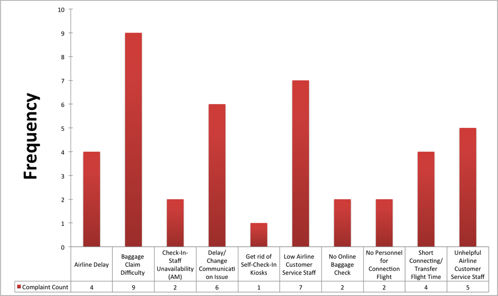

The barplot above shows the frequency of customer complaints for flights departing from San Francisco International Airport.

Chart Summary: Baggage claim issues account for ~ 22% of complaints, airline delay and communication issues account for ~ 24% of the complaints and staffing and customer issues account for ~ 34% of the complaints. Basing my conclusion solely on the survey data provided, I can conclude that these are the top 3 customer complaints from all flights departing SFO.

## Top 3 Customer Complaints Comparison: AA vs UA

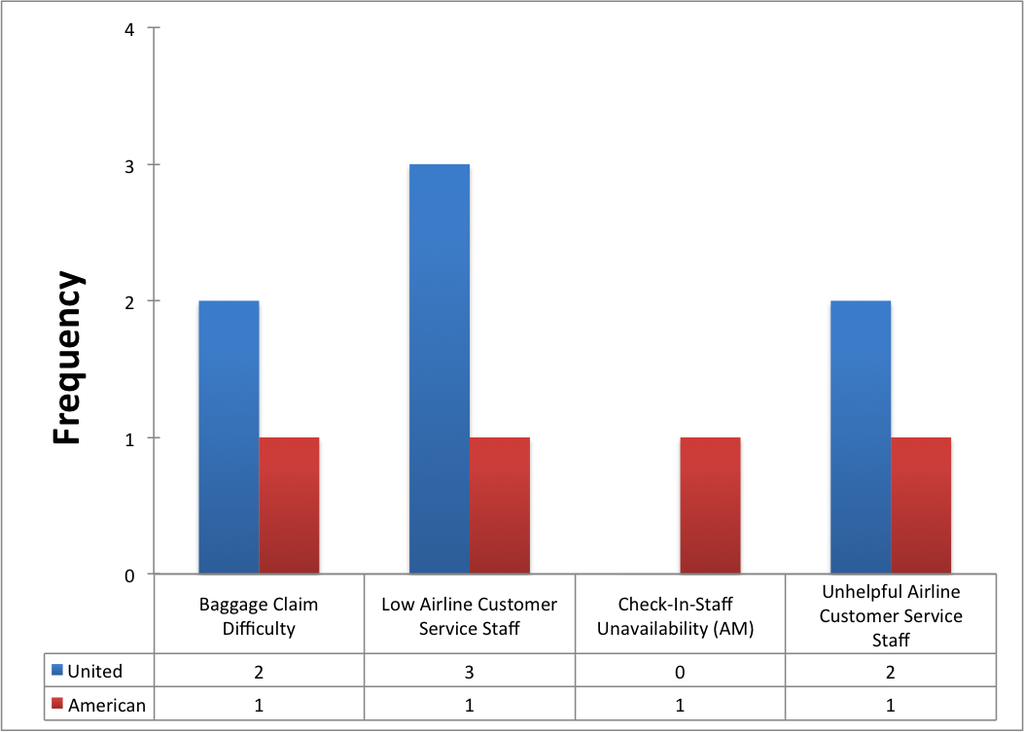

To evaluate AA data further, I compared AA to UA based on complaints similiarities. The chart above depicts this.

### Note:

*With departing flight count and customer size data unavailable, normalization to evaluate comparison extensively could not be carried out. As a result, data and results may be misleading.* Since the data is not normalized, this is not an apples-to-apples comparison. Although from the above barplot you would infer that UA has a higher count of complaints reported, without data on the total number of departing flights for each airline, it would be misleading to conclude on UA’s performance in comparison to AA. For example, if UA has double the number of flights departing from SFO compared to American, the complaint comparison chart becomes an equivalent comparison.

### Additional Data Analysis

Due to a lack of AA data and for a better understanding of what can be done with this data, I will analyze UA survey data.

*(continued on next page)*

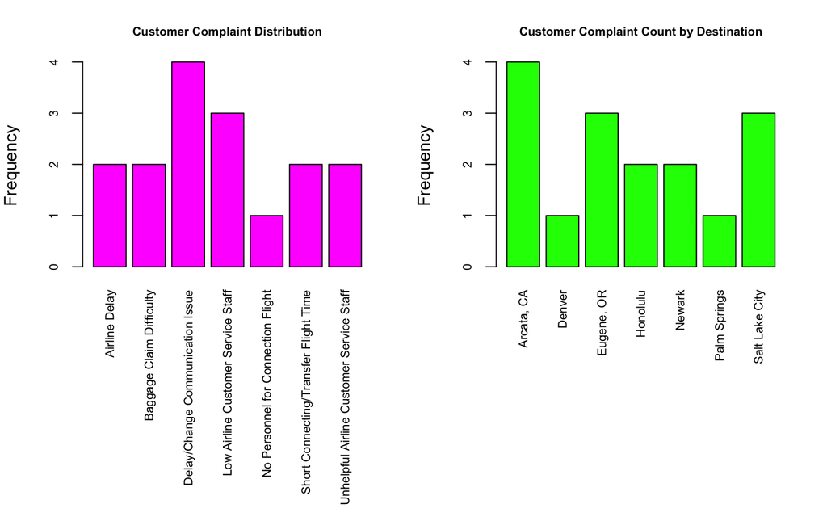

*Plots are based on United Airline survey data only*

### Customer Complaints Frequency by Flight Destination

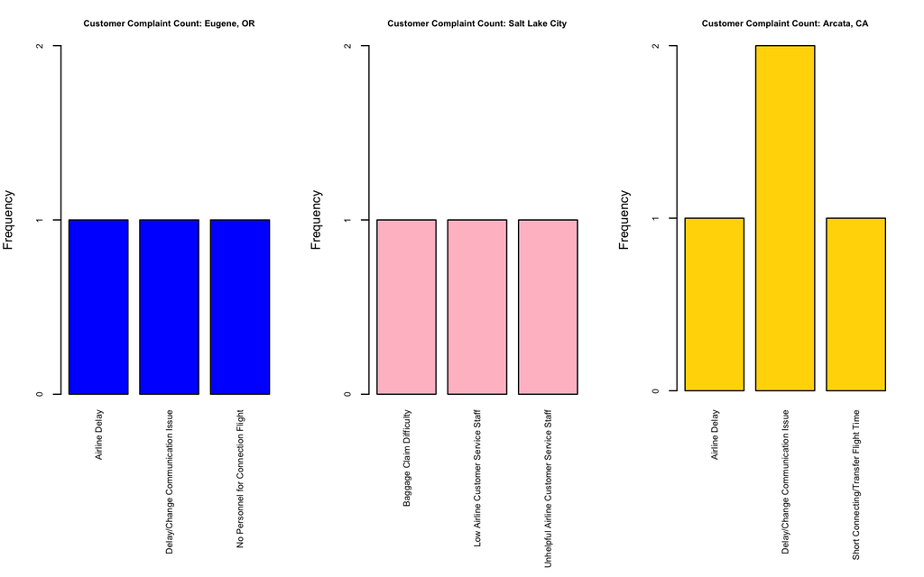

Plot 1 (Magenta) shows the distribution of customer complaints across all UA flights departing from SFO. Plot 2 (Green) shows the frequency of customer complaints by flight destination.

## Appendix

### Raw Data Snippet

Below is a snapshot of the cleaned data table.

```
##   AIRLINE FLIGHT DESTINATION DESTMARK  DEPTIME      HOWLONG Q8COM1
## 1       8    242          18        4 07:20:00 79.999999999     20
## 2      38   1777          99        2 08:00:00 119.99999999     NA
## 3      38   1777          99        2 08:00:00 104.99999999    999
## 4       8    242          18        4 07:20:00 19.999999999     NA
## 5      38   1777          99        2 08:00:00 134.99999999     NA
## 6      38   1777          99        2 08:00:00 119.99999999    103
```

Below are tabular representations of the barplot trio displayed in the previous page.

```
##      Destination No. of Complaints
## 1     Arcata, CA                 4
## 2         Denver                 1
## 3     Eugene, OR                 3
## 4       Honolulu                 2
## 5         Newark                 2
## 6   Palm Springs                 1
## 7 Salt Lake City                 3
```

```
##                                 Complaints Frequency
## 1                            Airline Delay         2
## 2                 Baggage Claim Difficulty         2
## 3         Delay/Change Communication Issue         4
## 4       Low Airline Customer Service Staff         3
## 5       No Personnel for Connection Flight         1
## 6    Short Connecting/Transfer Flight Time         2
## 7 Unhelpful Airline Customer Service Staff         2
```

## Complaint Comparison for Airlines with Similar Review Frequency

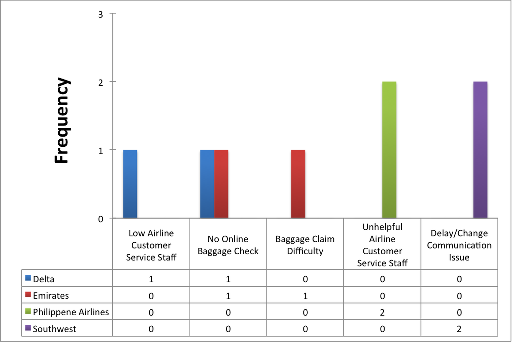

Although these airlines contained equal complaint counts, the complaints vary.

# Contact

email: nky@utexas.edu